*Putri Shafaa Salsabila*

# RSUP Sardjito

[figure not shown]

## RSUP SARDJITO

Kementrian Kesehatan Wilayah Sleman

### RSUP Sardjito

Rumah Sakit Umum Pusat Dr. Sardjito (bahasa Jawa: ꦫꦸꦩꦃꦱꦏꦶꦠ꧀ꦈꦩꦸꦩ꧀ꦥꦸꦱꦠ꧀ꦝꦺꦴꦏ꧀ꦠꦺꦂꦱꦂꦢ꧀ꦗꦶꦠ, translit. Rumah Sakit Umum Pusat Dhoktér Sardjita) adalah rumah sakit umum yang terletak di Kalurahan Sinduadi, Kapanéwon Mlati, Kabupaten Sleman, Daerah Istimewa Yogyakarta.

[Learn More](https://sardjito.co.id/profil-sardjito/)

#### Sejarah

Didirikan pada tahun 1982, rumah sakit ini segera menjadi mitra tetap Fakultas Kedokteran Universitas Gadjah Mada dalam menyelenggarakan pendidikan dokter, dokter spesialis, dan perawat.

#### layanan spesialis

Rumah Sakit ini mempunyai beragam layanan spesialis, yaitu penyakit dalam, jantung dan pembuluh darah, bedah umum, bedah orthopedi, bedah plastik, bedah thorax, jantung, dll.

#### alamat

Jl. Kesehatan Jl. Kesehatan Sendowo No.1, Sendowo, Sinduadi, Kec. Mlati, Kabupaten Sleman, Daerah Istimewa Yogyakarta 55281

[figure not shown]

### Kasus Demam Berdarah

Demam berdarah dengue (DBD) adalah penyakit yang ditularkan oleh gigitan nyamuk bernama Aedes aegypti. Penyakit ini masih menjadi salah satu isu kesehatan masyarakat di Indonesia, dan tingkat penyebarannya di Indonesia termasuk yang tertinggi di antara negara-negara Asia Tenggara.

##### Penyebab

- Virus dengue disebarkan oleh infeksi gigitan nyamuk Aedes Aegypti. Nyamuk tersebut mendapatkan virus dengan menggiggit orang yang telah terinfeksi.

##### Kasus

- Departemen Kesehatan Republik Indonesia mengumumkan bahwa ada sekitar 160.000 kasus Demam Berdarah Dengue (DBD) yang tercatat tersebar di 213 daerah di Indonesia

##### fakta

- Penyakit ini masih menjadi salah satu isu kesehatan masyarakat di Indonesia, dan tingkat penyebarannya di Indonesia termasuk yang tertinggi di antara negara-negara Asia Tenggara.

## Informasi Seputar Demam Berdarah

Sebab saat ini Kota Yogyakarta mengalami kenaikan kasus Demam Berdarah Dengue (DBD). Dimana hingga bulan April 2024 kasus DBD di Kota Yogyakarta sebanyak 99 kasus. Jumlah tersebut mengalami kenaikan dibandingkan pada tahun 2023 sebanyak 86 kasus.

### Bagaimana Virus DBD Menyebar

Virus dengue disebarkan oleh infeksi gigitan nyamuk Aedes Aegypti. Nyamuk tersebut mendapatkan virus dengan menggiggit orang yang telah terinfeksi. Gejala perdarahan berlangsung setelah terjadi demam selama 3-7 hari. Demam tinggi berlangsung selama 5-6 hari (39-40 C), lalu demam akan turn pada hari ketiga atau keempat namun setelah itu akan muncul lagi. Kita tidak bisa mengetahui nyamuk mana yang membawa virus dengue. Oleh karena itu, kita harus melindungi diri kita dari segala gigitan nyamuk.

### Gejala

Gejala utama penyakit DBD meliputi demam mendadak yang tinggi, mencapai suhu hingga 39 derajat celsius. Demam ini berlangsung terus-menerus selama 2-7 hari, kemudian turun dengan cepat. Gejala lain yang biasanya terjadi adalah nyeri kepala, menggigil, lemas, nyeri di belakang mata, otot, dan tulang, ruam kulit kemerahan, kesulitan menelan makanan dan minuman, mual, muntah, gusi berdarah, mimisan, timbul bintik-bintik merah pada kulit, muntah darah, dan buang air besar berwarna hitam. Pada fase kritis penyakit ini, suhu tubuh menurun dan tubuh terasa dingin, meskipun penderita mungkin merasa seperti sudah sembuh.

### Cara Menghindari

Untuk menghindari demam berdarah, yang harus kita lakukan adalah menghindari gigitan nyamuk pembawa virus dengue tersebut. Apa saja langkah-langkah yang bisa dilakukan?

- Menggunakan baju berlengan panjang dan menutupi tubuh.

- Menggunakan lotion anti nyamuk.

- Menggunakan obat anti nyamuk bakar atau elektrik di dalam ruangan pada siang hari.

- Pakaikan kelambu anti nyamuk pada bayi agar tidak tergigit nyamuk.

- Pastikan tubuh Anda selalu fit, karena jika tubuh kurang fit maka akan lebih cepat terinfeksi gigitan nyamuk.

## Berita

Berikut adalah beberapa berita atau Artikel terikini mengenai demam berdarah (DBD)

- 06 Mei 2024
- 12 Mei 2024
- 26 Maret 2024
- 22 November 2023
- 30 April 2024

### Waspada DBD, Gencarkan PSN dan 3M Plus

Portal Berita Pemerintah Jogjakarta, 06 Mei 2024

UMBULHARJO - Pemerintah Kota Yogyakarta melalui Dinas Kesehatan Kota Yogyakarta menghimbau warga Kota Yogyakarta untuk rutin melakukan Pemberantasan Sarang Nyamuk (PSN) 3M plus. Sebab saat ini Kota Yogyakarta mengalami kenaikan kasus Demam Berdarah Dengue (DBD). Dimana hingga bulan April 2024 kasus DBD di Kota Yogyakarta sebanyak 99 kasus. Jumlah tersebut mengalami kenaikan dibandingkan pada tahun 2023 sebanyak 86 kasus.

[Read me](https://warta.jogjakota.go.id/detail/index/33262)

[figure not shown]

### EDBD di DIY Tahun Ini Sampai 1.112 Kasus hingga Mei, 3 Orang Meninggal

DetikJogja, 12 Mei 2024

Jogja - Angka kasus Demam Berdarah Dengue (DBD) di Provinsi DIY melejit naik. Dinas Kesehatan (Diskes) DIY mencatat kasus DBD hingga Mei ini menyentuh angka 1.112 kasus. Angka tersebut meningkat pesat jika dibandingkan tahun lalu. Rini merinci kasus DBD terbanyak terjadi di Gunungkidul dengan total 603 kasus. Dua pasien di antaranya meninggal dunia pada Februari lalu. Kemudian di Sleman sebanyak 175 kasus dan 1 pasien meninggal dunia. Di Bantul ada 171 kasus, Kota Jogja 93 kasus, dan Kulon Progo 73

[Read me](https://www.detik.com/jogja/berita/d-7336112/dbd-di-diy-tahun-ini-sampai-1-112-kasus-hingga-mei-3-orang-meninggal)

[figure not shown]

### Kasus Demam Berdarah di Yogyakarta Capai Ratusan, 2 Meninggal, Terbanyak di Gunungkidul

Kompas Jogjakarta, 26 Maret 2024

YOGYAKARTA, KOMPAS.com - Kasus demam berdarah (DB) di Daerah Istimewa Yogyakarta (DIY) sampai 23 Maret 2024 tercatat mencapai ratusan. Kepala Bidang Pencegahan dan Pengendalian Penyakit Dinas Kesehatan DIY Setiyo Harini merinci, ratusan kasus DBD di DIY tersebut tersebar di Kota Yogyakarta 45 kasus, Bantul 76 kasus, Kulonprogo 34 kasus, Gunungkidul 311 kasus, dan Sleman 56 kasus. "Tapi memang angkanya bukan semua demam berdarah semua, kan ada demam berdarah dengue, ada demam dengue. Jadi ini menghitung juga yang demam dengue semua," ujarnya, saat dihubungi Selasa (26/3/2023).

Read me

[figure not shown]

### Delapan Tahun Lepas Nyamuk Ber-Wolbachia, Kota Yogyakarta Catatkan Rekor Kasus DBD Terendah Sepanjang Sejarah

Universitas Gadjah Mada, 22 November 2023

Kota Yogyakarta menjadi kota pertama di Indonesia yang mengimplementasikan teknologi nyamuk ber-Wolbachia dalam pengendalian demam berdarah dengue (DBD). Sejak program ini dimulai pada tahun 2016 lalu, angka kasus DBD di Kota Yogyakarta berangsur menurun, dan pada tahun 2023 mencatatkan rekor terendahnya di angka 67 kasus.

[Read me](https://ugm.ac.id/id/berita/delapan-tahun-lepas-nyamuk-ber-wolbachia-kota-yogyakarta-catatkan-rekor-kasus-dbd-terendah-sepanjang-sejarah/)

[figure not shown]

### Kasus DBD Masih Ada, Ayo tetap Waspada

Kementran Kesehatan Jogjakarta, 30 April 2024.

Penyakit dengue atau kita kenal sebagai demam berdarah dengue atau DBD merupakan penyakit yang masih menjadi masalah kesehatan masyarakat di DIY. Penyakit ini disebabkan oleh vius dengue yang ditularkan oleh nyamuk Aedes Aegypti maupun Aedes Albopictus dimana nyamuk tersebut telah menggigit manusia sebelumnya yang telah terinfeksi virus dengue. Rata-rata masa inkubasi (waktu yang diperlukan sejak tertular/terinfeksi hingga muncul gejala) penyakit dengue adalah 4-10 hari setelah digigit nyamuk

[Read me](https://dinkes.jogjaprov.go.id/berita/detail/kasus-dbd-masih-ada-ayo-tetap-waspada)

[figure not shown]

## Doctors

Berikut adalah beberapa dokter yang bekerja di Rumah Sakit Sardjito

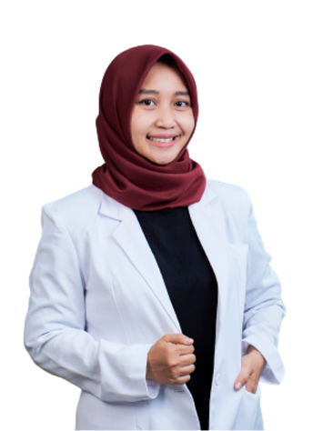

#### dr. AFRILIA INTAN PRATIWI, M.Sc., Sp.A

Dokter Spesialis Anak

Dokter Afril melayani konsultasi pasien anak di Poliklinik Alergi dan Imunologi Anak RSUP Dr. Sardjito dan memberikan pelayanan di bagian Kesehatan anak pada umumnya. Beliau menyelesaikan pendidikan dokter spesialis anak dan S2 di UGM serta mengikuti pelatihan mengenai alergi dan imunologi anak serta kasus reumatologi pada anak.

[figure not shown]

#### Dr. dr. DESHINTA PUTRI MULYA, M.Sc, Sp.PD,KAI

Dokter Konsulen Penyakit Dalam - Alergi Imunologi

Spesialis penyakit dalam Konsultan Alergi imunologi Klinik. Beliau menyelesaikan S1 dan spesialis penyakit dalamnya di FK UGM dan konsultan Sub Alergi dan Imunogi di fakultas Kedokteran Universitas Indonesia. Mengikuti training Imunologi yang diselenggarakan oleh The American Association of Immunologist di Pennsylvania, Philadelphia.

[figure not shown]

#### dr. AMELIA NUR VIDYANTI, Ph.D., Sp.S(K)

Dokter Konsulen Saraf - Neuro-Behaviour

dr. Amelia Nur Vidyanti, Sp.S(K), PhD adalah seorang dokter spesialis saraf konsultan neurobehaviour yang juga mendalami bidang neurorestorasi dan gangguan tidur. Beliau juga seorang peneliti di bidang demensia dan gangguan kognitif pasca-stroke. Beliau juga aktif mengisi berbagai acara edukasi awam terkait demensia dan ganguan tidur di youtube NB-INA dan radio RRI (pro2 populer).

[figure not shown]

#### dr. BANU AJI DIBYASAKTI, Sp.M

Dokter Spesialis Penyakit Mata

Ddr. Banu merupakan ahli rekonstruksi, okuloplasti dan onkologi mata. Mengambil pendidikan fellowship rekonstruksi, okuloplasti dan onkologi di Jakarta Eye Center. Kasus-kasus yang tangani yaitu kelainan seputar kelopak dan saluran air mata (ptosis, kekendoran otot & kulit kelopak mata, entropion, ektropion, mata berair, dll), rekonstruksi kelopak dan orbita (pasca kecelakaan pada mata) dan juga kasus tumor pada mata (meningioma, retinoblastoma, limfoma, Graves, dll).

### Testimonials

RSUP Dr Sardjito merupakan Rumah Sakit Pendidikan Kelas A. Mitra Terpercaya Menuju Sehat bagi Anda dan keluarga.

isi kuesioner Survei Kepuasan Pengguna terhadap Website dibawah ini

[Testimoni Web](https://forms.gle/bxZRtNy4he7NX89WA)

[figure not shown]

### Winda Yuliana

#### Ceo & Founder

One of the best hospitals in Indonesia..

[figure not shown]

### Putri Shafaa

#### Designer

As the Public Hospital, RSUP Sardjito is one of the best hospitals in Indonesia. It has good facilities and good medical system. We can do register for checking-up at clinics by online and it doesn't need to wait for long queue. The nurses are friendly and caring to each patient..

[figure not shown]

### Syuja Rizqullah

#### Store Owner

The biggest hospital in yogyakarya. This place serve many kind, almost all, of health care service. This place is very crowded during operational hours.

[figure not shown]

### Dzikra Ramadhan

#### Freelancer

One of the biggest hospital in Yogyakarta. I hope every year this hospital improve their system, service, technology, and many more for better future. Not only when accreditation but every time.

[figure not shown]

### Keysa Merdiana

#### Student

Well equipped and well staffed hospital. Service is impeccable, staff is professional and well trained. It is clean, well maintained, Parking is plentiful.

## Peta Tematik Daerah Persebaran Demam Berdarah dan Lokasi Rumah Sakit di Sleman

Peta tematik ini dirancang untuk memberikan visualisasi mengenai penyebaran Demam Berdarah Dengue (DBD) dan lokasi rumah sakit di Kabupaten Sleman. Peta ini mengidentifikasi dan menandai daerah rawan, sedang, dan aman terhadap DBD berdasarkan analisis data epidemiologi dan spasial. Selain itu, peta ini juga menampilkan pusat DBD dengan rumah sakit terdekat, termasuk jalur khusus menuju Rumah Sakit Umum Pusat Sardjito, sebagai salah satu pusat rujukan utama yang diharapkan dapat membantu masyarakat agar bisa mempermudah penanganan saat terkena Demam berdarah

[interactive chart not shown]

## Pendaftaran

Pendaftaran online dilakukan sebelum melakukan pemeriksaan

© **Putri Shafaa Salsabila**

22/496510/SV/20967